# Support-aware event studies

Use Lepskii-style designs to separate pooling structure from calendar-time support.

The partial-pooling family adapts an ongoing working-paper design for pooling across staggered-adoption cohorts. Names and details may change with that work.

## 1 Scientific question

An event-study estimator faces two distinct problems:

1. Cohorts can have different effect paths.
2. A cohort-event comparison can fall outside the observed calendar.

Pooling can reduce variance when cohort paths are similar. It can add bias when they differ. No amount of pooling creates a missing calendar-time observation.

```python
import matplotlib.pyplot as plt
import numpy as np

from pypanelsim import designs

print(designs.available_lepskii_designs())
```

```
('complete_homogeneity', 'common_path', 'cohort_only_blocks', 'time_only_blocks', 'tensor_blocks', 'early_late_split', 'three_epoch', 'smooth_dose_gradient', 'response_timing', 'local_window_shock', 'log_shark_sin', 'no_pool_unique_signatures', 'no_pool_unique_peaks', 'no_pool_signed_paths')
```

## 2 Panel design

The default panel has 1,200 units, 36 periods, and nine adoption cohorts. The untreated outcome combines unit effects, time effects, periodic time terms, and errors correlated across units and time.

Each named variant changes only the cohort-specific effect paths. The variants cover:

- complete or common-path homogeneity;
- cohort blocks, time blocks, and cohort-time tensor blocks;
- early-versus-late cohorts and three time epochs;
- smooth dose gradients and response-timing differences;
- local shocks and damped waves;
- fully cohort-specific signatures, peaks, or signed paths.

## 3 Compare pooling structures

```python
config = designs.LepskiiPanelConfig(n_units=360)

for name in (
    "complete_homogeneity",
    "tensor_blocks",
    "no_pool_signed_paths",
):
    profiles = designs.lepskii_profiles(name, config=config)
    first_cohort = min(profiles)
    print(name, np.round(profiles[first_cohort][:6], 2))
```

```
complete_homogeneity [1.4 1.4 1.4 1.4 1.4 1.4]
tensor_blocks [0.45 0.45 0.45 0.45 2.5  2.5 ]
no_pool_signed_paths [0.   0.4  0.71 0.95 1.14 1.28]
```

The mapping key is the adoption period. Each value is the post-adoption path for that cohort.

## 4 Run a tensor-block design

```python
panel = designs.lepskii(
    "tensor_blocks",
    config=config,
    seed=42,
)

print(panel.shape)
print(np.unique(panel.adoption_times[panel.ever_treated]))
print(round(panel.true_att, 3))
```

```
(360, 36)
[ 8 10 12 14 16 18 20 22 24]
1.32
```

## 5 Cohort paths and calendar support

The left panel shows the tensor-block effect paths. The right panel shows which cohort-event cells lie inside the observed calendar.

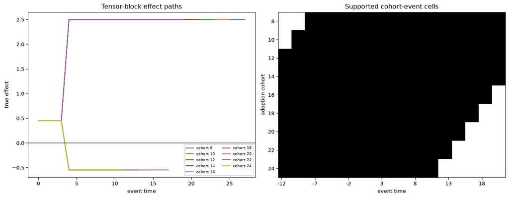

Figure 1: Cohort effect paths and the calendar-time support mask for a tensor-block design.

```python
profiles = designs.lepskii_profiles("tensor_blocks", config=config)
event_grid = np.arange(-12, 22)
truth_grid = panel.truth.cohort_event(event_times=event_grid)
cohorts = np.unique(truth_grid["cohort"])
support = truth_grid["supported"].reshape(cohorts.size, event_grid.size)

figure, axes = plt.subplots(1, 2, figsize=(13, 5), constrained_layout=True)
for cohort, profile in profiles.items():
    axes[0].plot(
        np.arange(profile.size),
        profile,
        label=f"cohort {cohort}",
    )
axes[0].axhline(0.0, color="black", linewidth=0.7)
axes[0].set_xlabel("event time")
axes[0].set_ylabel("true effect")
axes[0].set_title("Tensor-block effect paths")
axes[0].legend(ncol=2, fontsize=7)

axes[1].imshow(support, aspect="auto", cmap="Greys", vmin=0, vmax=1)
axes[1].set_xticks(np.arange(0, event_grid.size, 5))
axes[1].set_xticklabels(event_grid[::5])
axes[1].set_yticks(np.arange(cohorts.size))
axes[1].set_yticklabels(cohorts)
axes[1].set_xlabel("event time")
axes[1].set_ylabel("adoption cohort")
axes[1].set_title("Supported cohort-event cells")
plt.show()
```

## 6 Track support explicitly

For cohort $g$ and event time $e$, the calendar period is $t=g+e$. The cell is supported only when $0\le t<T$.

```python
cells = panel.truth.cohort_event(event_times=(-12, -4, 0, 4, 12, 20))

for cohort in np.unique(cells["cohort"]):
    selected = cells["cohort"] == cohort
    print(
        "cohort",
        int(cohort),
        "events",
        cells["event_time"][selected],
        "support",
        cells["supported"][selected],
    )
```

```
cohort 8 events [-12  -4   0   4  12  20] support [False  True  True  True  True  True]
cohort 10 events [-12  -4   0   4  12  20] support [False  True  True  True  True  True]
cohort 12 events [-12  -4   0   4  12  20] support [ True  True  True  True  True  True]
cohort 14 events [-12  -4   0   4  12  20] support [ True  True  True  True  True  True]
cohort 16 events [-12  -4   0   4  12  20] support [ True  True  True  True  True False]
cohort 18 events [-12  -4   0   4  12  20] support [ True  True  True  True  True False]
cohort 20 events [-12  -4   0   4  12  20] support [ True  True  True  True  True False]
cohort 22 events [-12  -4   0   4  12  20] support [ True  True  True  True  True False]
cohort 24 events [-12  -4   0   4  12  20] support [ True  True  True  True False False]
```

Unsupported effects are `NaN`. They are not zeros. This distinction prevents an estimator or plot from treating “not observed” as “no effect.”

## 7 Define the event-time target

At a fixed event time, different cohorts can contribute because of calendar support. The target population therefore changes with event time.

```python
size_weighted = panel.truth.event_study(
    event_times=range(-4, 13),
    weighting="cohort_size",
)
equal_cohort = panel.truth.event_study(
    event_times=range(-4, 13),
    weighting="equal_cohort",
)

for index in range(0, len(size_weighted["event_time"]), 4):
    print(
        int(size_weighted["event_time"][index]),
        round(float(size_weighted["effect"][index]), 3),
        round(float(equal_cohort["effect"][index]), 3),
        int(size_weighted["supported_cohorts"][index]),
    )
```

```
-4 0.0 0.0 9
0 0.45 0.45 9
4 1.199 1.144 9
8 1.199 1.144 9
12 1.313 1.356 8
```

The two weighting rules answer different questions. A simulation report should name the rule and show the number of supported cohorts at each event time.

## 8 A clean Monte Carlo grid

A useful grid crosses pooling structure with noise and sample size:

```python
design_names = (
    "complete_homogeneity",
    "cohort_only_blocks",
    "tensor_blocks",
    "no_pool_signed_paths",
)
noise_scales = (0.5, 1.0, 2.0)
unit_counts = (600, 1200, 2400)
```

Hold the event-time target and support rule fixed across this grid. Then changes in bias or coverage can be attributed to the estimator’s pooling decision, rather than to a silent change in the estimand.